Luan Rezende Eduardo

### Introdução

Visa-se com este trabalho analisar os dados da série de retornos aproximada obtida a partir do log da diferença da série de preços do ativo financeiro PETR4, modelando a sua média condicional através de um modelo ARIMA e sua volatilidade condicional através de um modelo GARCH, de forma a obter predições sobre o seu comportamento fora da amostra.

A sigla PETR4 se refere as ações preferenciais da estatal brasileira Petrobras S.A. e os códigos utilizados podem ser encontradas no link https://github.com/luanreduardo/econometrics_stocks.

### Análise Exploratória

Utiliza-se a base de dados da Economática contendo os preços de fechamento do ativo PETR4 entre os anos de 1996 e 2019, convertidos em uma série temporal do tipo xts. Após a remoção dos dias de não-atividade do mercado tem-se os preços conforme o seguinte gráfico.

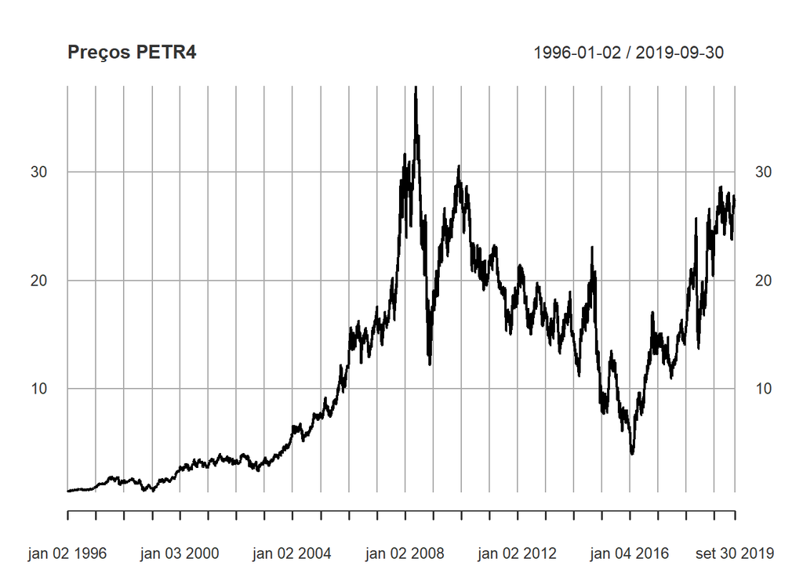

Posteriormente, aplica-se a diferença do logaritmo para obter uma série aproximada de retornos para este ativo, com o objetivo de obter uma série estacionária, uma vez que esta é condição necessária para a modelagem. Obtém-se, então, a série abaixo.

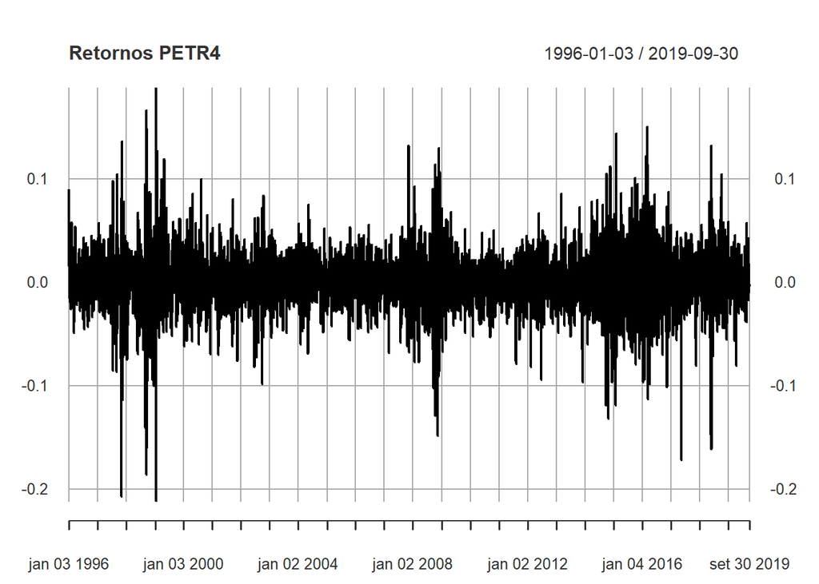

A partir dos dados aparentemente estacionários da série de retornos, testamos a estacionariedade através de um teste de Dickey-Fuller aumentado, com o número de defasagens sugerido pela função como a raiz cúbica do tamanho da amostra menos 1. Nesse teste a H0 aponta para um passeio aleatório, o presente resultado rejeita H0 indicando a estacionariedade da série.

```
##
##  Augmented Dickey-Fuller Test
##
## data:  petr4_returns
## Dickey-Fuller = -16.601, Lag order = 18, p-value = 0.01
## alternative hypothesis: stationary
```

Por último, calcula-se as funções de autocorrelação e autocorrelação parcial para se verificar se os seus decaimentos indicam a estacionariedade, os resultados abaixo tem rápido decaimento e corroboram o indicado no teste de Dickey-Fuller.

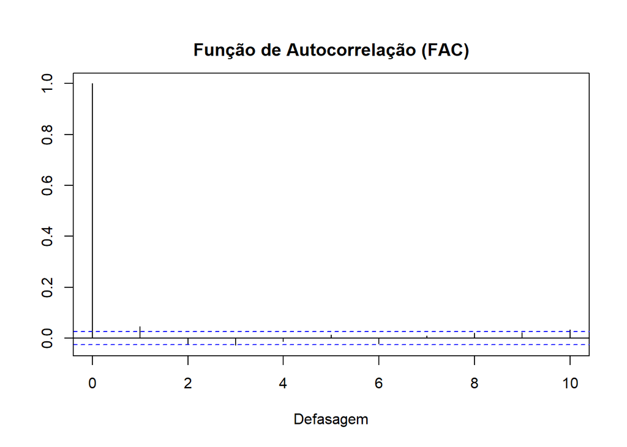

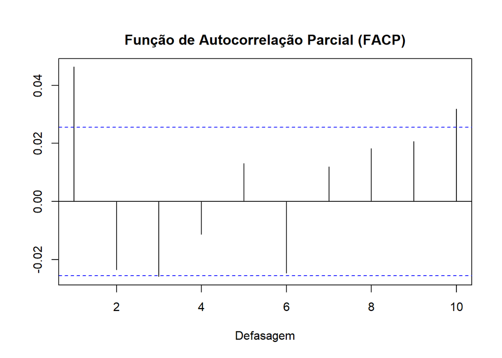

### Modelagem do ARIMA

Para determinar as ordens máximas $p$, $d$ e $q$ utiliza-se os resultados obtidos na análise exploratória. Como a série dos retornos, utilizada a partir daqui, já apresenta estacionariedade não há necessidade de diferenciação adicional, logo $d=0$. Já os gráficos da FAC e da FACP indicam, respectivamente, um MA(1) e um AR(1) máximos, dessa forma testaremos todos os modelos entre ARIMA(0,0,0) e ARIMA(1,0,1).

```
##       spec log_likelihood qt_parameters size       AIC       BIC
## 1 ARIMA000       12733.20             2 5872 -25462.39 -25449.04
## 2 ARIMA100       12739.51             3 5872 -25473.02 -25452.98
## 3 ARIMA001       12739.79             3 5872 -25473.57 -25453.54
## 4 ARIMA101       12740.32             4 5872 -25472.64 -25445.93
```

Os resultados indicam que modelo de menor AIC e BIC é o ARIMA(0,0,1), ou MA(1), com três parâmetros. Esse, portanto, é o escolhido para os próximos passos.

```
##
## Call:
## arima(x = petr4_returns, order = c(0, 0, 1), method = "ML")
##
## Coefficients:
##          ma1  intercept
##       0.0484      7e-04
## s.e.  0.0133      4e-04
##
## sigma^2 estimated as 0.0007639:  log likelihood = 12739.79,  aic = -25473.57
```

### Análise dos Resíduos para o MA(1)

Aqui é feita uma análise dos resíduos para verificar se existem indicativos de padrões não esperados, uma vez que esses devem se comportar como um ruído branco. Para isso, inicia-se com um teste de Ljung-Box para testar se há indicativo de autocorrelação serial dos resíduos, onde o objetivo é aceitar a hipótese de que os resíduos são i.i.d, H0. Tem-se um p-valor < 0.05, evidência contra H0.

```
##
##  Box-Ljung test
##
## data:  cond_average$residuals
## X-squared = 85.189, df = 63, p-value = 0.03281
```

Utiliza-se a FAC dos resíduos, indica a ausência de uma autocorrelação.

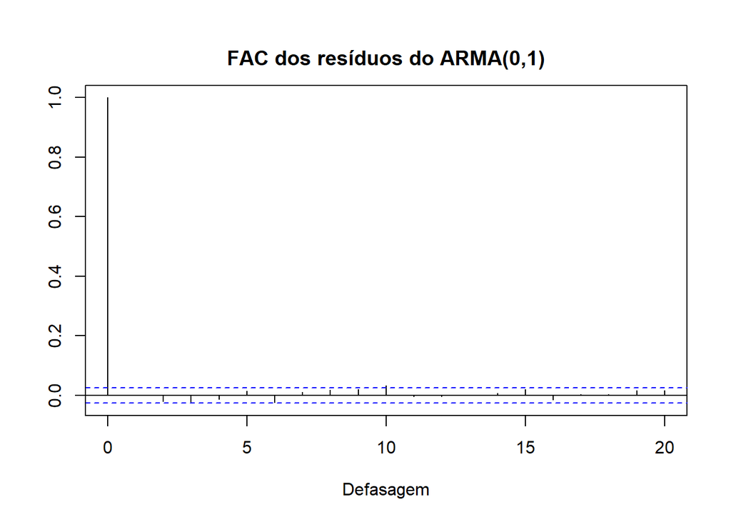

Já a FAC dos resíduos ao quadrado indica a existência de uma heterocedasticidade condicional nos dados, o que corrobora um fato estilizado do mercado financeiro, que apresenta clusters de volatilidade e onde o módulo de $t-1$ afeta o valor de $t$.

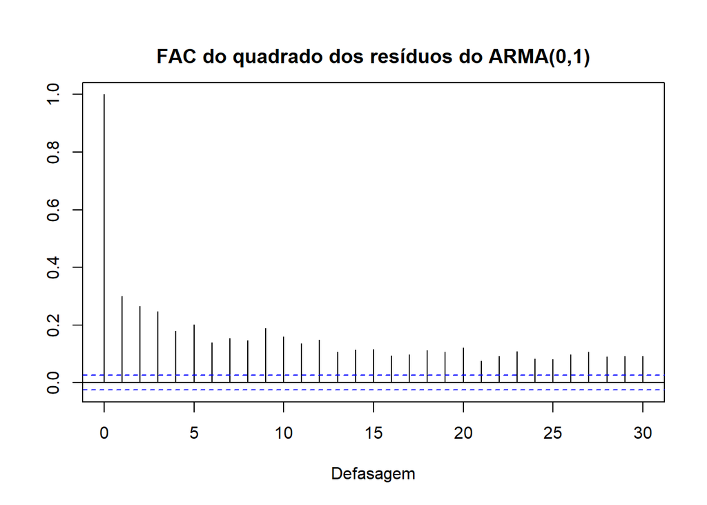

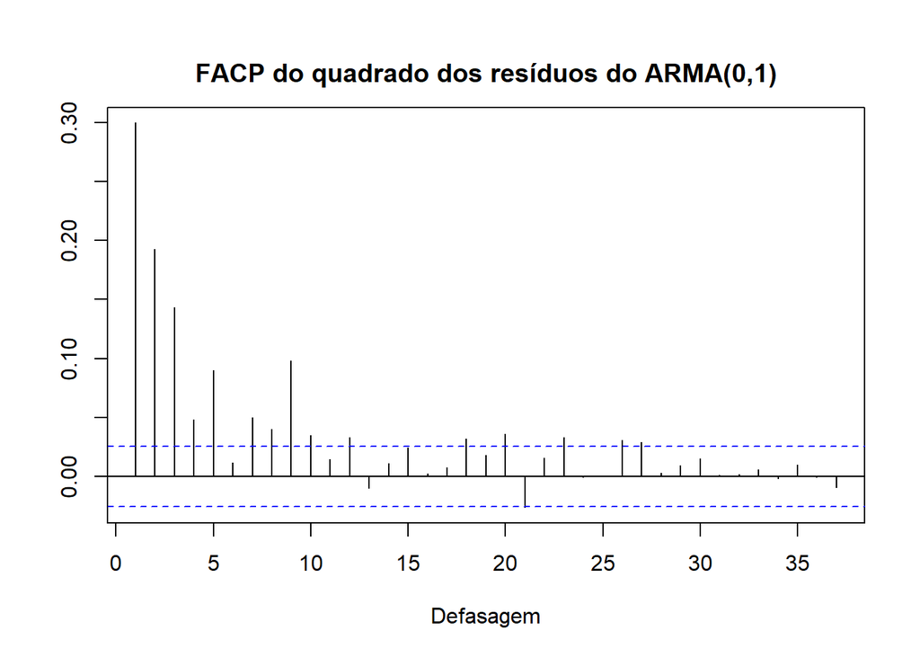

A não realização dos testes de Shapiro e Jarque-Bera para normalidade da distribuição dos resíduos é justificado pela pouca confiabilidade de seus resultados para grande amostras, uma vez que pequenas distorções na distribuição já causam a rejeição da hipótese de normalidade adotada para o modelo.

### Modelo ARMA-GARCH

A presença de heterocedasticidade condicional evidenciada pelas funções de autocorrelação e autorrelação parcial torna necessária a adição de uma ferramenta de modelagem da variância condicional da série temporal. Portanto, busca-se a partir daqui modelar um ARIMA-GARCH para os dados.

As funções de FAC e FACP dos resíduos ao quadrados indicam as ordens $m$ e $n$ máximas do modelo de variância condicional GARCH, uma vez que o FAC não entram na banda de aceitação em defasagens muito altas de cientes de que altas ordens não são usuais, opta-se por $m=5$ e $n=5$ conforme FACP. Os resultados de cada composição de ordens segue abaixo, a distribuição adotada foi a t assimétrica.

```
##                  spec ln_likelihood param_number sample_size       aic
## 1  ~arma(0,1)-garch10     -13357.82            5        5872 -4.547963
## 2  ~arma(0,1)-garch20     -13469.02            6        5872 -4.585498
## 3  ~arma(0,1)-garch30     -13525.34            7        5872 -4.604339
## 4  ~arma(0,1)-garch40     -13557.91            8        5872 -4.615092
## 5  ~arma(0,1)-garch50     -13582.15            9        5872 -4.623008
## 6  ~arma(0,1)-garch11     -13663.62            6        5872 -4.651779
## 7  ~arma(0,1)-garch21     -13663.58            7        5872 -4.651424
## 8  ~arma(0,1)-garch31     -13663.53            8        5872 -4.651067
## 9  ~arma(0,1)-garch41     -13663.50            9        5872 -4.650714
## 10 ~arma(0,1)-garch51     -13663.48           10        5872 -4.650367
## 11 ~arma(0,1)-garch12     -13663.55            7        5872 -4.651412
## 12 ~arma(0,1)-garch22     -13663.97            8        5872 -4.651215
## 13 ~arma(0,1)-garch32     -13663.91            9        5872 -4.650855
## 14 ~arma(0,1)-garch42     -13663.87           10        5872 -4.650499
```

[output cut: 47 more lines]

Os resultados de obtidos indicam menores AIC e BIC no modelo ARMA(0,1)-GARCH(1,1), definindo o modelo utilizado no restante desse trabalho.

```
##
## *---------------------------------*
## *          GARCH Model Fit        *
## *---------------------------------*
##
## Conditional Variance Dynamics
## -----------------------------------
## GARCH Model  : sGARCH(1,1)
## Mean Model   : ARFIMA(0,0,1)
## Distribution : sstd
##
## Optimal Parameters
## ------------------------------------
##         Estimate  Std. Error  t value Pr(>|t|)
## mu      0.001196    0.000293   4.0845 0.000044
## ma1     0.043826    0.013606   3.2212 0.001277
## omega   0.000015    0.000003   5.0656 0.000000
## alpha1  0.095911    0.010185   9.4167 0.000000
## beta1   0.884728    0.008183 108.1185 0.000000
## skew    0.980684    0.018097  54.1898 0.000000
## shape   7.449034    0.717432  10.3829 0.000000
##
## Robust Standard Errors:
##         Estimate  Std. Error  t value Pr(>|t|)
## mu      0.001196    0.000301   3.9729 0.000071
## ma1     0.043826    0.013858   3.1624 0.001565
## omega   0.000015    0.000005   3.0661 0.002169
## alpha1  0.095911    0.016591   5.7810 0.000000
## beta1   0.884728    0.007175 123.3108 0.000000
## skew    0.980684    0.018583  52.7731 0.000000
## shape   7.449034    0.889329   8.3760 0.000000
##
## LogLikelihood : 13658.74
##
## Information Criteria
## ------------------------------------
##
## Akaike       -4.6498
## Bayes        -4.6418
## Shibata      -4.6498
```

[output cut: 46 more lines]

```
## Negative Sign Bias  2.30475 0.0212151  **
## Positive Sign Bias  1.66932 0.0951075   *
## Joint Effect       16.46468 0.0009105 ***
##
##
## Adjusted Pearson Goodness-of-Fit Test:
## ------------------------------------
##   group statistic p-value(g-1)
## 1    20     13.14       0.8315
## 2    30     21.26       0.8494
## 3    40     28.11       0.9021
## 4    50     33.94       0.9498
##
##
## Elapsed time : 1.65431
```

### Análise dos Resíduos MA(1)-GARCH(1,1)

```
##
##  Box-Ljung test
##
## data:  fGarch::residuals(chosen_arma_garch, standardize = TRUE)
## X-squared = 60.811, df = 63, p-value = 0.5548
```

Abaixo, o gráfico da função de autocorrelação dos resíduos padronizados ao quadrado também sugere a ausência de heterocedasticidade.

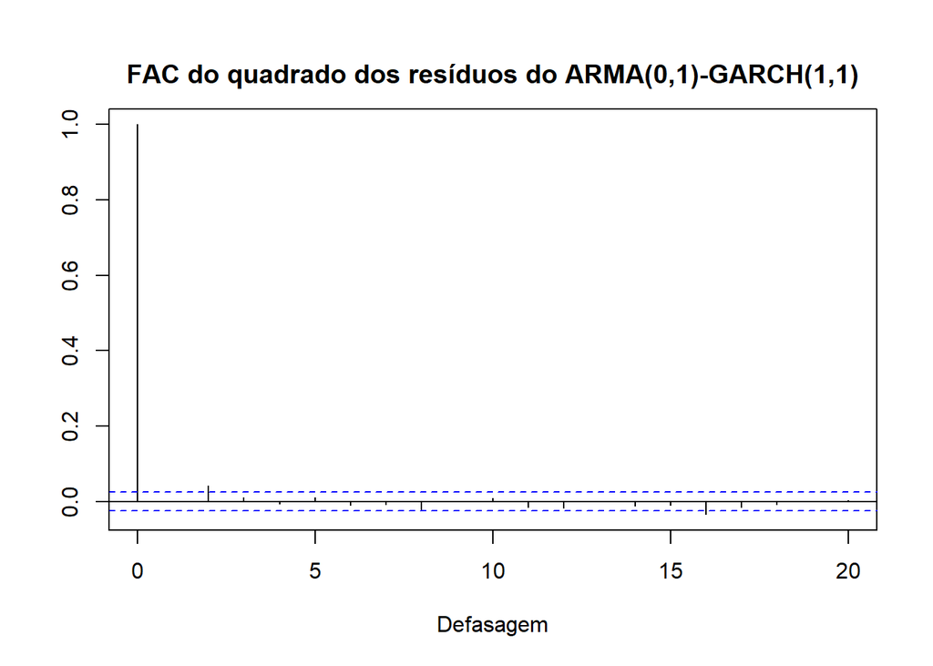

O modelo proposto parece capturar os padrões dos dados e a análise dos resíduos mostra que eles apresentam um bom comportamento

O resultado do ARMA(0,1)-GARCH(1,1) é expresso no gráfico abaixo

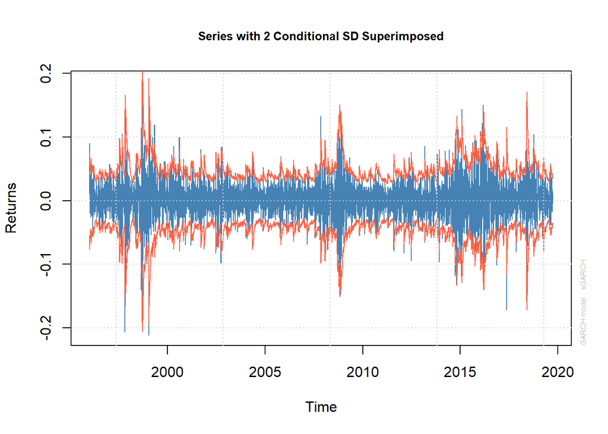

### Predições e acurácia

Por fim, uma previsão de 63 períodos é calculada com os seguintes valores de média e variância para cada período $T + i$ a partir de 30 de setembro de 2019.

```
##
## *------------------------------------*
## *       GARCH Model Forecast         *
## *------------------------------------*
## Model: sGARCH
## Horizon: 63
## Roll Steps: 0
## Out of Sample: 0
##
## 0-roll forecast [T0=2019-09-30]:
##         Series   Sigma
## T+1  0.0009746 0.01701
## T+2  0.0011955 0.01727
## T+3  0.0011955 0.01753
## T+4  0.0011955 0.01777
## T+5  0.0011955 0.01801
## T+6  0.0011955 0.01824
## T+7  0.0011955 0.01846
## T+8  0.0011955 0.01868
## T+9  0.0011955 0.01889
## T+10 0.0011955 0.01909
## T+11 0.0011955 0.01929
## T+12 0.0011955 0.01948
## T+13 0.0011955 0.01967
## T+14 0.0011955 0.01985
## T+15 0.0011955 0.02002
## T+16 0.0011955 0.02019
## T+17 0.0011955 0.02036
## T+18 0.0011955 0.02052
## T+19 0.0011955 0.02068
## T+20 0.0011955 0.02083
## T+21 0.0011955 0.02098
## T+22 0.0011955 0.02112
## T+23 0.0011955 0.02127
## T+24 0.0011955 0.02140
## T+25 0.0011955 0.02154
## T+26 0.0011955 0.02167
## T+27 0.0011955 0.02180
## T+28 0.0011955 0.02192
## T+29 0.0011955 0.02204
```

[output cut: 19 more lines]

```
## T+49 0.0011955 0.02394
## T+50 0.0011955 0.02401
## T+51 0.0011955 0.02409
## T+52 0.0011955 0.02416
## T+53 0.0011955 0.02422
## T+54 0.0011955 0.02429
## T+55 0.0011955 0.02436
## T+56 0.0011955 0.02442
## T+57 0.0011955 0.02448
## T+58 0.0011955 0.02455
## T+59 0.0011955 0.02461
## T+60 0.0011955 0.02467
## T+61 0.0011955 0.02472
## T+62 0.0011955 0.02478
## T+63 0.0011955 0.02484
```

A partir do qual plota-se os gráficos contendo os dados in-sample desde maio até o final de setembro, com a previsão dentro da banda de 1 sigma e também a previsão para o sigma incondicional, respectivamente.

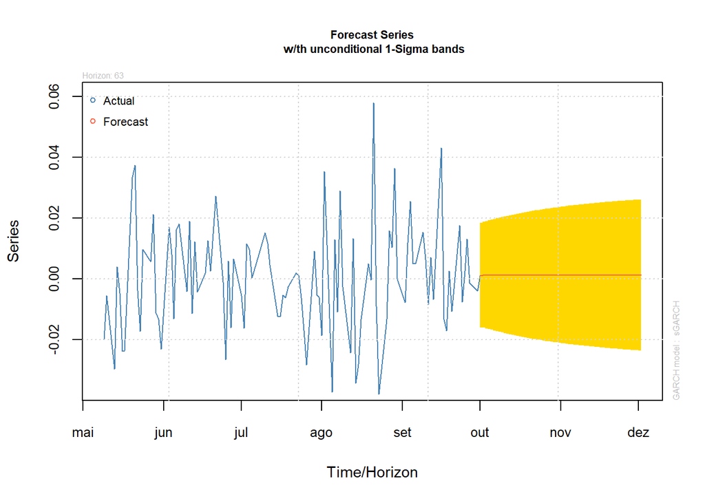

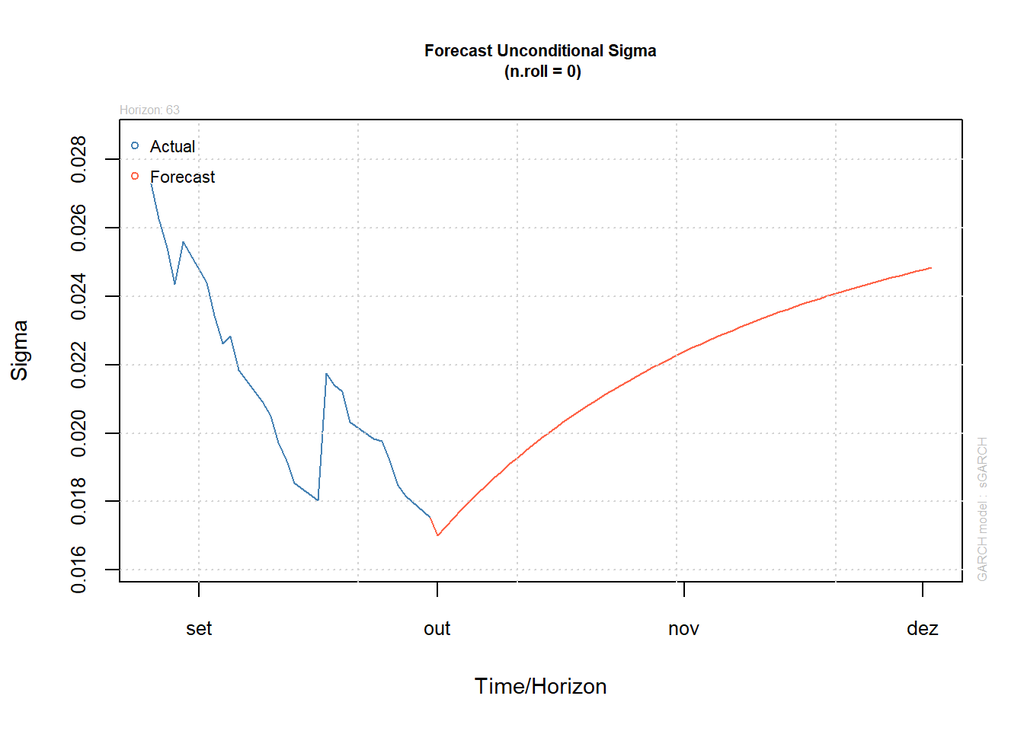

Um gráfico com os as previsões de média (em verde) e uma banda de dois sigma (média + sigma, média - sigma; em vermelho) juntamente com os dados de retornos dos meses de outubro, novembro e dezembro é plotado.

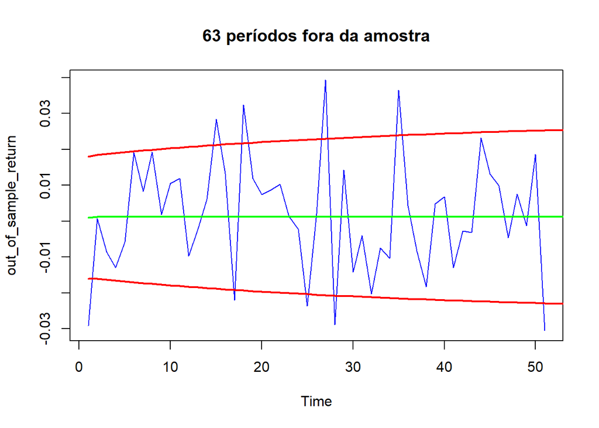

Conclui-se com o teste de acurácia, onde o média a série de erros (ME) se apresenta baixa, assim como a média das raizes do erros quadráticos (RMSE) e do valor absoluto do erro (MAE) também apresentam valores baixos. A média da série de erros percentual (MPE) e de erro absoluto percentual (MAPE) tem valores próximos ao 100%, indicando que o modelo tem pouco poder preditivo. Este resultado condiz com os fatos estilizados do mercado onde qualquer padrão tende a se dissipar pela ação de arbitragem dos agentes.

```
##                    ME       RMSE        MAE      MPE     MAPE
## Test set 0.0005338995 0.01607075 0.01273942 96.87605 99.22019
```

#### Códigos

```r
#packages
library(readxl)
library(xts)
library(zoo)
library(PerformanceAnalytics)

#loading data into a dataframe
closing_prices <- readxl::read_xlsx('data/acoesBR.xlsx', na = "-", )

#creating the index
date_string <- as.Date(closing_prices$Data)

#creating the time series
petr4_xts <- xts::xts(closing_prices[, 393], order.by = date_string)
colnames(petr4_xts) <- "PETR4"

#excluding NAs
petr4_xts <- na.omit(petr4_xts)

#sub-setting to 1996 up to september/2019
petr4_xts <- petr4_xts['1996/2019-09']

#calculating log returns
petr4_returns <- PerformanceAnalytics::Return.calculate(petr4_xts, method = "log")
petr4_returns <- na.omit(petr4_returns)

saveRDS(petr4_xts, file = "data/petr4.rds")
saveRDS(petr4_returns, file = "data/p4_returns.rds")

###########################################################

#exploratory analysis

library(xts)
library(fUnitRoots)
library(stats)
library(tseries)

#reading data
petr4_xts <- readRDS('data/petr4.rds')
petr4_returns <- readRDS('data/p4_returns.rds')

#plotting the timeseries of prices and returns
plot.xts(petr4_xts$PETR4, main = "Preços PETR4")
plot.xts(petr4_returns, main = "Retornos PETR4")

#testing stationarity, H0 points to random walk
unit_root <- tseries::adf.test(petr4_returns)

#auto-correlation and partial ac functions
acf_petr4_ret <- stats::acf(petr4_returns, na.action = na.pass, plot = FALSE, lag.max = 10)
pacf_petr4_ret <- stats::pacf(petr4_returns, na.action = na.pass, plot = FALSE, lag.max = 10)

par(mfrow = c(2,1))
plot(acf_petr4_ret, main = "", ylab = "", xlab = "Defasagem")
title("Função de Autocorrelação (FAC)", adj = 0.5, line = 1)
plot(pacf_petr4_ret, main = "", ylab = "", xlab = "Defasagem")
title("Função de Autocorrelação Parcial (FACP)", adj = 0.5, line = 1)
par(mfrow = c(1,1))


############################################################

#ARIMA modelling

library(stats)


#loading data
petr4_returns <- readRDS('data/p4_returns.rds')

#possibilities equal to or smaller than the last lag of ACF/PACF
feasible_set <- expand.grid(ar = 0:1, diff = 0, ma = 0:1)

#defining a list for the results
model <- list()

#estimating parameters through maximum likelihoood
for (i in 1:nrow(feasible_set)) {
  model[[i]] <- stats::arima(petr4_returns, order = unlist(feasible_set[i, 1:3]), method = "ML")
}

#greater value through log of ML
log_likelihood <- list()
for (i in 1:length(model)) {
  log_likelihood[[i]] <- model[[i]]$loglik
}

#AIC
aicarma <- list()
for (i in 1:length(model)) {
  aicarma[[i]] <- stats::AIC(model[[i]])
}

#BIC
bicarma <- list()
for (i in 1:length(model)) {
  bicarma[[i]] <- stats::BIC(model[[i]])
}

#number of parameters
qt_parameters <- list()
for (i in 1:length(model)) {
  qt_parameters[[i]] <- length(model[[i]]$coef) + 1 # + error's variance
}

#table of results
spec <- paste0("ARIMA",feasible_set$ar, feasible_set$diff, feasible_set$ma)
size <- rep(length(petr4_returns), length(model))
results <- data.frame(spec, log_likelihood = unlist(log_likelihood),
                             qt_parameters = unlist(qt_parameters),
                             size, AIC = unlist(aicarma),
                             BIC = unlist(bicarma), stringsAsFactors = FALSE)
print(results)

#chosen arima model
cond_average <- arima(petr4_returns, order = c(0,0,1), method = "ML")


###################################################################

#residuals analysis

library(stats)
library(tseries)
library(lmtest)

#autocorrelation function for the residuals
acf_residuals <- stats::acf(cond_average$residuals, na.action = na.pass, plot = FALSE, lag.max = 20)
plot(acf_residuals, main = "", ylab = "", xlab = "Defasagem")
title("FAC dos resíduos do ARMA(0,1)", adj = 0.5, line = 1)

#Ljung-Box
box_test_arma <- stats::Box.test(cond_average$residuals, lag = 63, type = "Ljung-Box") #check lags
print(box_test_arma)

#autocorrelation function, and partial acf, for the squared residuals
acf_residuals_square <- acf(cond_average$residuals^2,
                            na.action = na.pass, plot = FALSE, lag.max = 30)
plot(acf_residuals_square, main = "", ylab = "", xlab = "Defasagem")
title("FAC do quadrado dos resíduos do ARMA(0,1)", adj = 0.5, line = 1)
pacf_residuals_square <- stats::pacf(cond_average$residuals^2,
                                     plot = FALSE, na.action = na.pass, max.lag = 30)
plot(pacf_residuals_square, main = "", ylab = "", xlab = "Defasagem")
title("FACP do quadrado dos resíduos do ARMA(0,1)", adj = 0.5, line = 1)

#tests for the distribution of the resilduals, H0: follows a normal dist.
#shapiro_test <- stats::shapiro.test(na.remove(cond_average$residuals))
#jarque_bera <- tseries::jarque.bera.test(na.remove(cond_average$residuals))
#print(jarque_bera)


######################################################################

#Garch modelling

library(fGarch)
library(xts)
library(stats)
library(rugarch)

#all possible m, n for garch modelling
pars_arma_garch <- expand.grid(m = 1:5, n = 0:5)

#list for results
arma_garch_model <- list()

#arma specification defined on previous codes
arma_set <- "~arma(0,1)"

# probability distribution for the residuals (norm, std, snorm, sstd)
arma_residuals_dist <- "sstd"

#skew and assimetry definitions
include.skew = FALSE
include.shape = TRUE

#parameters estimation through maximum likelihood
for (i in 1:nrow(pars_arma_garch)) {
  arma_garch_model[[i]] <- fGarch::garchFit(as.formula(paste0(arma_set,"+","garch(",pars_arma_garch[i,1],",",pars_arma_garch[i,2], ")")),
                                             data = petr4_returns, trace = FALSE, cond.dist = arma_residuals_dist,
                                             include.skew = include.skew, include.shape = include.shape)
}

# function maximum value
log_likelihood_arma_garch <- list()
for (i in 1:length(arma_garch_model)) {
  log_likelihood_arma_garch[[i]] <- arma_garch_model[[i]]@fit$llh
}

# AIC
aicarma_garch <- list()
for (i in 1:length(arma_garch_model)) {
  aicarma_garch[[i]] <- arma_garch_model[[i]]@fit$ics[1]
}

# BIC
bicarma_garch <- list()
for (i in 1:length(arma_garch_model)) {
  bicarma_garch[[i]] <- arma_garch_model[[i]]@fit$ics[2]
}

# number of estimated parameters
arma_garch_param_number <- list()
for (i in 1:length(arma_garch_model)) {
  arma_garch_param_number[[i]] <- length(arma_garch_model[[i]]@fit$coef)
}

# table of results
spec <- paste0(arma_set,"-","garch",pars_arma_garch$m,pars_arma_garch$n)
sample_size <- rep(length(petr4_returns), length(arma_garch_model))
results_arma_garch <- data.frame(spec, ln_likelihood = unlist(log_likelihood_arma_garch),
                                 param_number = unlist(arma_garch_param_number),
                                 sample_size, aic = unlist(aicarma_garch), bic = unlist(bicarma_garch),
                                 stringsAsFactors = FALSE, row.names = NULL)
print(results_arma_garch)

#using rugarch modelling package for it provides greater possibilities of analysis
ugarch_version_spec <- rugarch::ugarchspec(variance.model = list(garchOrder = c(1,1)),
                                  mean.model = list(armaOrder = c(0,1)), distribution.model = "sstd")
chosen_arma_garch <- rugarch::ugarchfit(spec = ugarch_version_spec, data = petr4_returns)
print(chosen_arma_garch)


######################################################################

# ARMA-GARCH residual analysis

library(fGarch)
library(stats)

# squared residuals acf
acf_residuals_square_arma_garch <- acf(fGarch::residuals(chosen_arma_garch, standardize = TRUE)^2,
                                       na.action = na.pass, plot = FALSE, lag.max = 20)
plot(acf_residuals_square_arma_garch, main = "", ylab = "", xlab = "Defasagem")
title("FAC do quadrado dos resíduos do ARMA(0,1)-GARCH(1,1)", adj = 0.5, line = 1)

#Ljung-Box
box_test_garch <- stats::Box.test(fGarch::residuals(chosen_arma_garch, standardize = TRUE),
                            lag = 63, type = "Ljung-Box") #check lags
print(box_test_garch)


########################################################################

#Results and accuracy

library(stats)
library(fGarch)
library(rugarch)
library(forecast)
library(quantmod)
library(PerformanceAnalytics)
library(xts)

#plotting selected arma-garch model
fGarch::plot(chosen_arma_garch, which = 'all')
fGarch::plot(chosen_arma_garch, which = 1)

#out-of-sample data from quantmod
out_of_sample_prices <- quantmod::getSymbols(Symbols = "PETR4.SA", src = "yahoo", from = '2019-10-01')
out_of_sample_return <- na.omit(PerformanceAnalytics::Return.calculate(PETR4.SA$PETR4.SA.Close, method = "log"))

#plotting out-of-sample return set
plot.xts(out_of_sample_return, main = "Dados fora da amostra - PETR4")

#forecasting 3 months out of sample
arima_garch_forecast <- rugarch::ugarchforecast(chosen_arma_garch, n.ahead = 63)
print(arima_garch_forecast)
fGarch::plot(arima_garch_forecast, which = 1)
fGarch::plot(arima_garch_forecast, which = 3)

#plotting forecast against out-of-sample data
mean_arma_garch <- arima_garch_forecast@forecast$seriesFor
upper_bound_garch <- arima_garch_forecast@forecast$seriesFor + arima_garch_forecast@forecast$sigmaFor
lower_bound_garch <- arima_garch_forecast@forecast$seriesFor - arima_garch_forecast@forecast$sigmaFor

ylim <- c(min(out_of_sample_return), max(out_of_sample_return))
plot.ts(out_of_sample_return , col = "blue", ylim = ylim, main = '63 períodos fora da amostra')
lines(mean_arma_garch,col = "green", ylim = ylim, lwd  = 2)
lines(upper_bound_garch, col = "red", ylim = ylim, lwd = 2)
lines(lower_bound_garch, col = "red", ylim = ylim, lwd = 2)

#accuracy
accuracy_test_set <- forecast::accuracy(as.ts(arima_garch_forecast@forecast$seriesFor), out_of_sample_return)
```